# External Source Attribution and Adaptation while Viewing the Hand

Raphael Gastrock

# Overview

This document discusses figures and statistics for the Hand View project. The four main sections include data and analyses with regards to Learning Curves, Reach Aftereffects, Localization, and Contributions of proprioception and predictions to reach aftereffects.

# Setting up the R environment

Our scripts require the use of certain packages. If some packages are not available in your own system, run the command:

> install.packages(c(‘ez’, ‘svglite’, ‘phia’, ‘afex’, ‘lsmeans’, ‘scales’, ‘lsr’, ‘tools’, ‘usdm’, ‘lmtest’, ‘car’, ‘rockchalk’, ‘tidyr’))

We have written code that pre-processes the data, plots figures, and runs statistical tests. Import the sources below:

```r
source('R/shared.R')
source('R/learningCurves.R')
source('R/noCursor.R')
source('R/localization.R')
source('R/awareness.R')
source('R/cursortrajectory.R')
source('R/data.R')
```

Then we need to ensure that the data is available locally. We download the pre-processed data available from OSF. If the files already exist, the output will indicate this.

```r
getPreprocessedData()
```

[output not shown]

Once the data and code are available, we can proceed to the next sections.

# Learning Curves

First, we aimed to determine the effects of manipulating the extent of attributing the source of errors externally, on reaching movements while experiencing a 30° CW rotation.

Cursor training trials for both aligned and rotated sessions were manually inspected for failing to perform the required reach, e.g. not reaching the target with a smooth and straight movement. Trials that were not useable for further analyses were removed. For the remaining trials, we calculated angular deviation of the hand at the point of maximum velocity. This is the angular difference between a line connecting the home position to the target and a line connecting the home position to the participant’s hand position at the peak of their movement velocity. Thus, in order to fully compensate for the cursor-rotation, participants had to deviate their reaches in the 30° CCW direction. We corrected for individual baseline biases, by calculating the average reach deviation for each target separately within each participant, during the last 30 out of the first 45 aligned cursor training trials, and subtracting this from cursor training trials in the rotated session.

## Show the data

Below is a plot of the angular deviation of the hand across the first 90 trials of the rotated session. Lines represent the mean angular deviation of each group in every trial, and corresponding shaded regions represent 95% Confidence Intervals. For a closer look, we also show the same data, but only for the first 15 and last 15 trials.

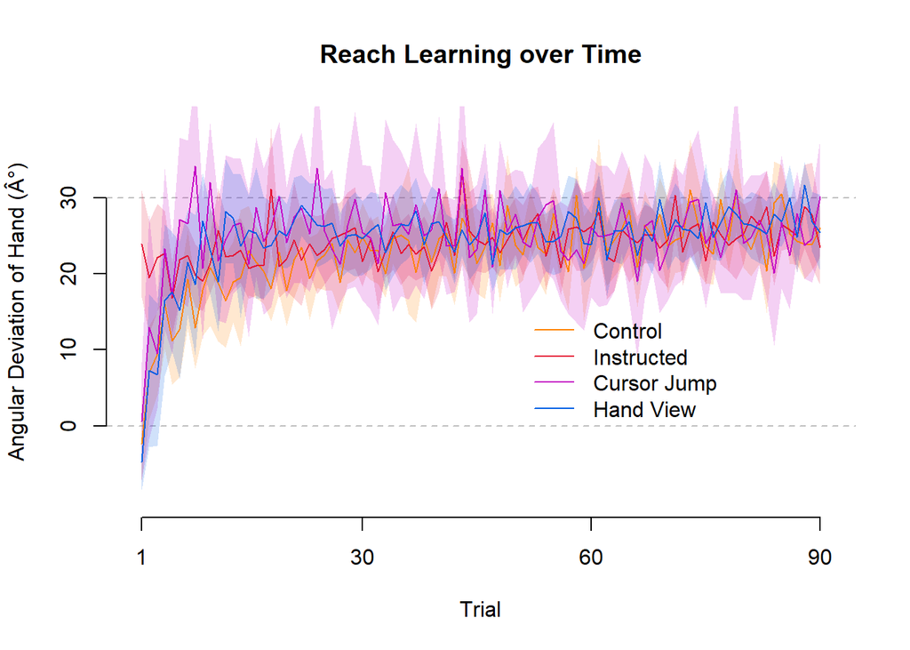

```r
plotFullLearningCurves(target='inline')
```

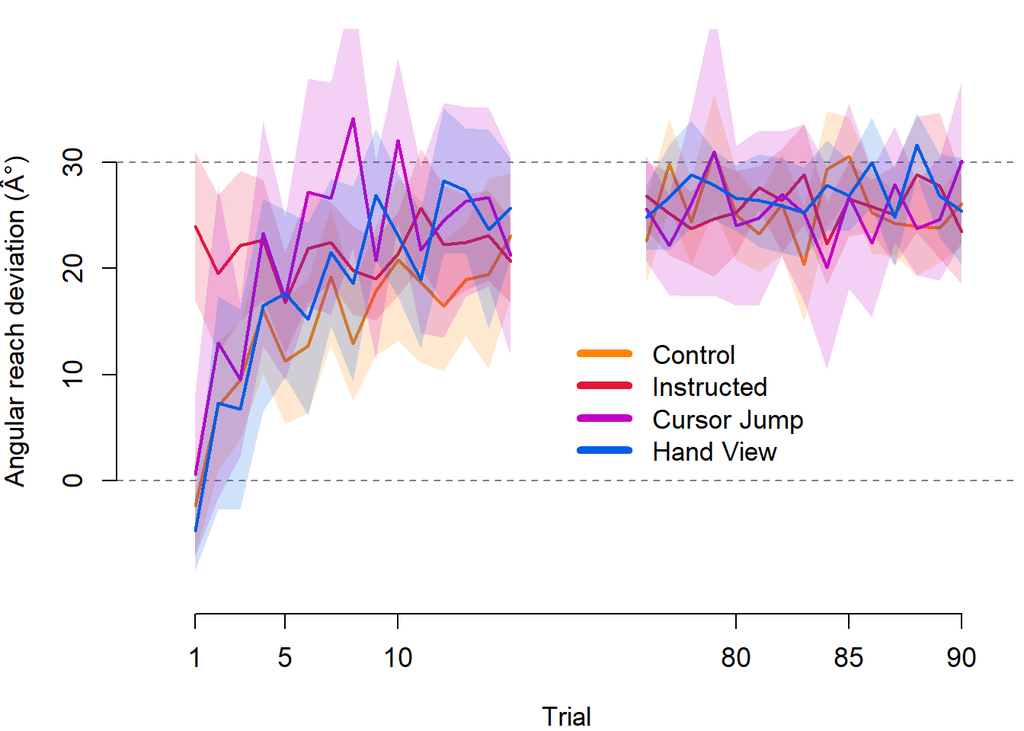

```r
plotBlockedLearningCurves(target='inline')
```

We see that, during training, the Instructed Group countered the rotation immediately, while the other groups took longer (within 15-20 trials) to compensate for the cursor-rotation. All groups performed similar reaching movements at the end of training.

We also show individual and average reach trajectories for all groups, during the aligned session, early adaptation training, and late adaptation training. From this plot, we observe that reach trajectories are similar in pattern across all groups, regardless of manipulations to the extent of external error attribution.

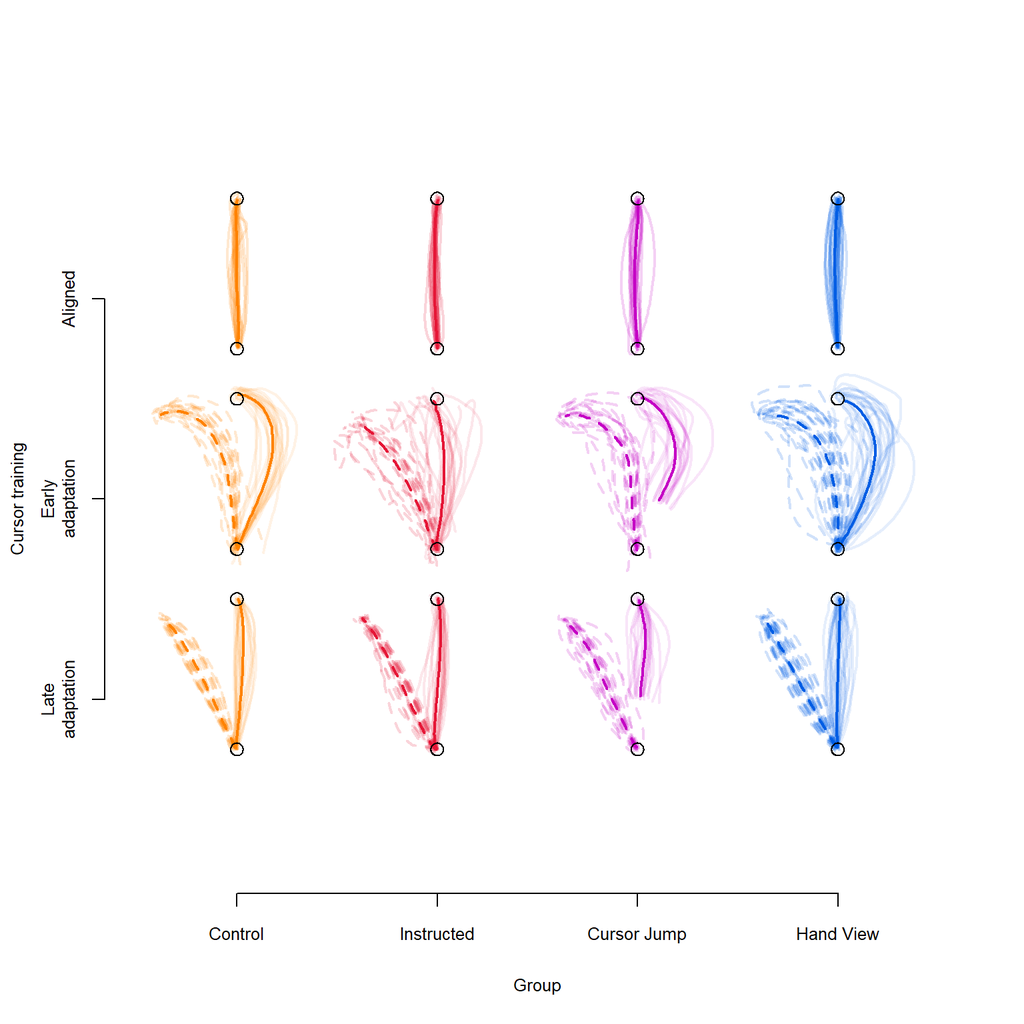

```r
plotAllTrajectories()
```

## ANOVAs

To analyze the effects of our manipulation on rates of learning, we blocked the rotated training data into three blocks of trial sets. The first block consisted of the first set of three trials, the second consisted of the next three trials, and the third consisted of the last 15 trials of rotated training. Below is a plot showing individual participant data for each group across these three blocks (i.e. transparent dots). Solid dot and error bars represent the mean and bootstrapped 95% confidence intervals.

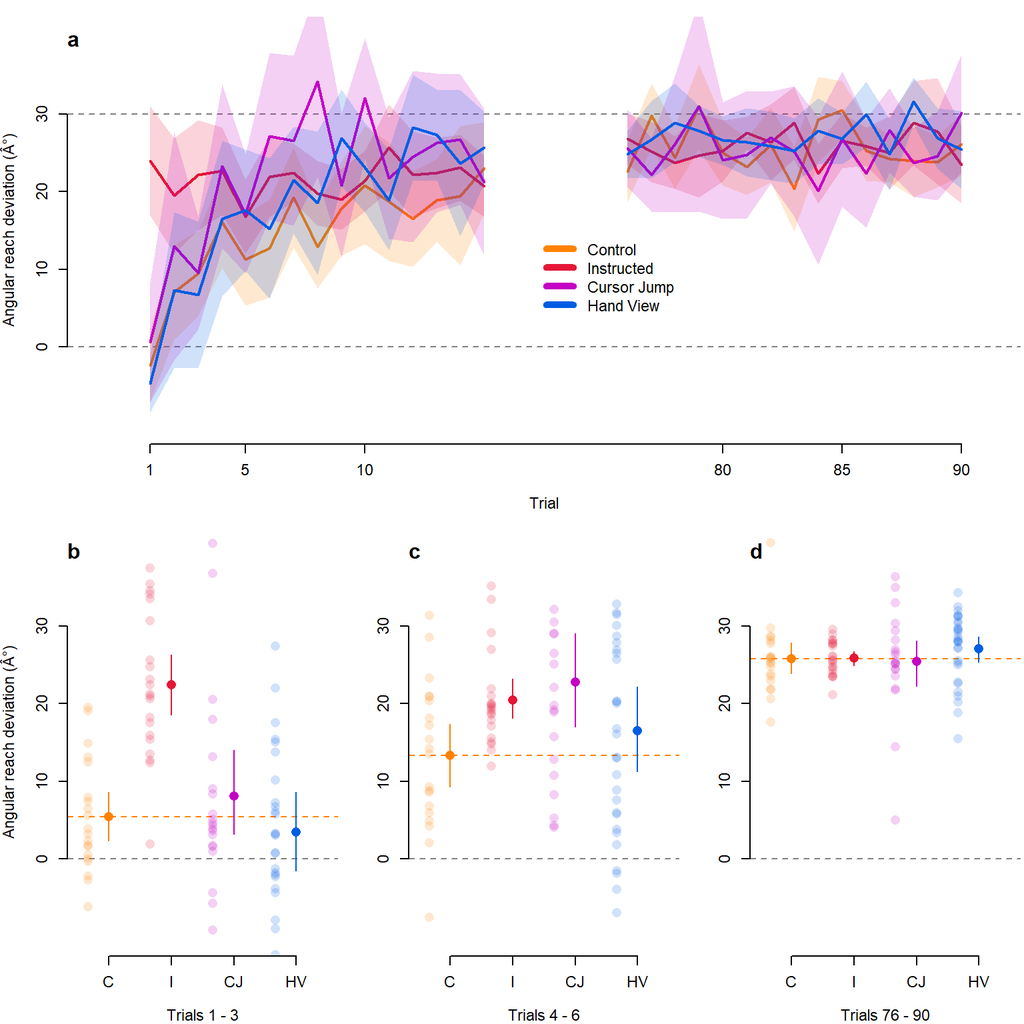

```r
plotLearningCurves()
```

We proceeded to investigate how the four groups and their performance during adaptation training, compared with each other, for each of these three blocks. We performed a 3X4 mixed design ANOVA with block as a within-subject factor (blocks 1, 2, and 3) and group as a between-subject factor (Control, Instructed, Cursor Jump, Hand View). For this and the following tests, the alpha level was set to 0.05 and, when necessary, Greenhouse Geisser corrections were applied.

```r
learningCurveANOVA()
```

```
## $ANOVA
##            Effect DFn DFd         F            p p<.05        ges
## 2       diffgroup   3  86  5.677939 1.350501e-03     * 0.09235814
## 3           block   2 172 78.410892 6.263779e-25     * 0.30716530
## 4 diffgroup:block   6 172  7.855695 1.733714e-07     * 0.11758332
##
## $`Mauchly's Test for Sphericity`
##            Effect         W         p p<.05
## 3           block 0.9813597 0.4494693
## 4 diffgroup:block 0.9813597 0.4494693
##
## $`Sphericity Corrections`
##            Effect       GGe        p[GG] p[GG]<.05      HFe        p[HF]
## 3           block 0.9817008 1.605131e-24         * 1.004419 6.263779e-25
## 4 diffgroup:block 0.9817008 2.189187e-07         * 1.004419 1.733714e-07
##   p[HF]<.05
## 3         *
## 4         *
```

We see that the main effects of group and block, and their interaction, were statistically significant. This suggests that the rate of learning of at least one group differed from the other groups and that this difference was dependent on the block of trials. Hence, it was appropriate to look at differences between groups in each block.

## Planned follow-up tests

```r
learningcurveComparisonMeans()
```

```
## Contrasts set to contr.sum for the following variables: diffgroup
```

```
##  diffgroup  block  lsmean   SE  df lower.CL upper.CL
##  30explicit first   22.29 2.17 227   18.009    26.56
##  30implicit first    5.22 2.21 229    0.863     9.58
##  cursorjump first    7.91 2.21 229    3.550    12.26
##  handview   first    3.29 1.93 213   -0.519     7.10
##  30explicit second  20.24 2.17 227   15.960    24.51
##  30implicit second  13.16 2.21 229    8.800    17.51
##  cursorjump second  22.62 2.21 229   18.264    26.98
##  handview   second  16.28 1.93 213   12.469    20.08
##  30explicit last    25.68 2.17 227   21.402    29.96
##  30implicit last    25.55 2.21 229   21.197    29.91
##  cursorjump last    25.25 2.21 229   20.894    29.61
##  handview   last    26.86 1.93 213   23.056    30.67
##
## Warning: EMMs are biased unless design is perfectly balanced
## Confidence level used: 0.95
```

```r
getComparisonEffSize(method='sidak', type='two')
```

```
## Contrasts set to contr.sum for the following variables: diffgroup
```

```
##  contrast                          estimate   SE  df t.ratio p.value
##  Block1: Instr vs. Non-instr          17.07 3.68 148  4.632  <.0001
##  Block1: Cursor Jump vs. Non-instr     2.69 3.73 148  0.721  0.9784
##  Block1: Hand View vs. Non-Instr      -1.93 3.43 148 -0.563  0.9940
##  Block2: Instr vs. Non-instr           7.08 3.68 148  1.922  0.2949
##  Block2: Cursor Jump vs. Non-instr     9.46 3.73 148  2.538  0.0709
##  Block2: Hand View vs. Non-instr       3.12 3.43 148  0.910  0.9339
##
## P value adjustment: sidak method for 6 tests
##                            contrast  etasquared
## 1       Block1: Instr vs. Non-instr 0.126622848
## 2 Block1: Cursor Jump vs. Non-instr 0.003496956
## 3   Block1: Hand View vs. Non-Instr 0.002139995
## 4       Block2: Instr vs. Non-instr 0.024346324
## 5 Block2: Cursor Jump vs. Non-instr 0.041710549
## 6   Block2: Hand View vs. Non-instr 0.005568593
```

In block one, when each group was compared to the Control group, only the Instructed group differed significantly. This suggests that only the instructed group had an initial advantage in learning to counter for the rotation of the cursor. In block two, however, no groups significantly differed from the Control group, suggesting that the learning across groups did not differ from each other for this block. Note that effect sizes are provided with eta-squared, which is interpreted as the percent of variance in angular reach deviation that is accounted for by the difference between the given group and the control, Control group.

To summarize, instruction on the nature of the perturbation and being given a strategy to counter it, creates an initial advantage in reducing hand direction error when reaching towards a target with a rotated cursor. However, our other manipulations, despite the error being more clearly external in nature, do not produce a similar initial advantage.

## Confirmatory Analyses for follow-up tests

In addition to our planned follow-up tests, we also conducted extra analyses that will support our findings. First, in the multiple pairwise comparisons we conduct above, contrasts were specified specifically for blocks 1 and 2. However, if we include the last block into these contrasts and comparisons, the calculated results will differ in some manner.

```r
getComparisonEffSize(method='sidak', type='all')
```

```
## Contrasts set to contr.sum for the following variables: diffgroup
```

```
##  contrast                          estimate   SE  df t.ratio p.value
##  Block1: Instr vs. Non-instr         17.067 3.13 225  5.452  <.0001
##  Block1: Cursor Jump vs. Non-instr    2.687 3.17 225  0.848  0.9895
##  Block1: Hand View vs. Non-Instr     -1.931 2.91 225 -0.663  0.9983
##  Block2: Instr vs. Non-instr          7.081 3.13 225  2.262  0.2012
##  Block2: Cursor Jump vs. Non-instr    9.465 3.17 225  2.987  0.0278
##  Block2: Hand View vs. Non-instr      3.120 2.91 225  1.072  0.9512
##  Block3: Instr vs. Non-instr          0.125 3.13 225  0.040  1.0000
##  Block3: Cursor Jump vs. Non-instr   -0.303 3.17 225 -0.096  1.0000
##  Block3: Hand View vs. Non-instr      1.310 2.91 225  0.450  0.9999
##
## P value adjustment: sidak method for 9 tests
##                            contrast   etasquared
## 1       Block1: Instr vs. Non-instr 1.166885e-01
## 2 Block1: Cursor Jump vs. Non-instr 3.187346e-03
## 3   Block1: Hand View vs. Non-Instr 1.950291e-03
## 4       Block2: Instr vs. Non-instr 2.223195e-02
## 5 Block2: Cursor Jump vs. Non-instr 3.814713e-02
## 6   Block2: Hand View vs. Non-instr 5.076500e-03
## 7       Block3: Instr vs. Non-instr 7.076083e-06
## 8 Block3: Cursor Jump vs. Non-instr 4.060224e-05
## 9   Block3: Hand View vs. Non-instr 8.987414e-04
```

The main different result would be that the Cursor Jump group is now statistically different from the Control group, within the second block. This suggests that the Cursor Jump group’s rate of learning was faster than the Control group for this block, but this does not provide any further advantage, as the magnitude of asymptotic learning across all groups do not differ from each other by the end of adaptation training. Support for this comes from the lack of statistical significance for comparisons within the last block (as shown above), as well as an additional One-way ANOVA we conduct on reach deviations for only the last block (as shown below).

```r
lastblockANOVA()
```

```
## Coefficient covariances computed by hccm()
```

```
## $ANOVA
##      Effect DFn DFd         F         p p<.05        ges
## 2 diffgroup   3  86 0.5613904 0.6419415       0.01920724
##
## $`Levene's Test for Homogeneity of Variance`
##   DFn DFd      SSn      SSd        F         p p<.05
## 1   3  86 69.79376 1036.468 1.930359 0.1306884
```

# Reach aftereffects

We then investigated the effect of manipulating the extent of external error attribution on reach aftereffects.

Similar to the Learning Curves section, reaches in no-cursor trials for both aligned and rotated sessions were manually inspected for failing to perform the required reach. Trials that were not useable for further analyses were removed. For the retained trials, we used the endpoint angle to calculate for the angular deviation of the hand. This is the angular difference between the point where the participant’s hand movement ended and the target. Angular reach deviations from aligned no-cursor trials were subtracted from without strategy no-cursor trials to confirm whether training with a rotated cursor led to reach aftereffects.

## Show the data

Below is a plot of the mean angular reach deviation for each group as a function of either excluding or including a strategy. Lines represent the mean angular deviation of each group, and corresponding shaded regions represent 95% Confidence Intervals. Individual participant data are shown as transparent dots.

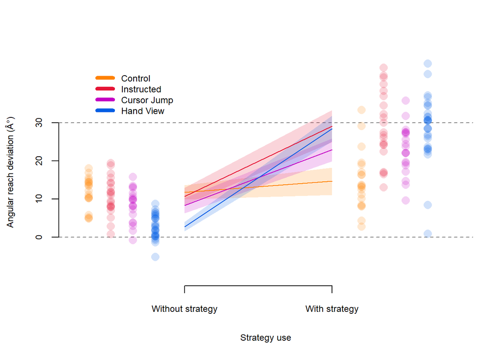

```r
plotGroupReachAfterEffects()
```

We see from the figure that when including or excluding the strategy learned to counter the rotation, only the Control group could not switch their strategy on or off at will. This suggests unawareness of learning for this group. Importantly, all groups still showed angular reach deviations to some degree during without strategy trials, showing that implicit reach aftereffects were still observed in all groups. Note, however, that implicit reach aftereffects were smaller for the Hand View group compared to the other groups.

Below is a plot showing individual data points for reach aftereffects and strategy use across all groups. The left panel is the same as the plot shown above. For the centre and right panels, solid dots and error bars represent the mean and bootstrapped 95% confidence intervals, and transparent dots represent individual participant data.

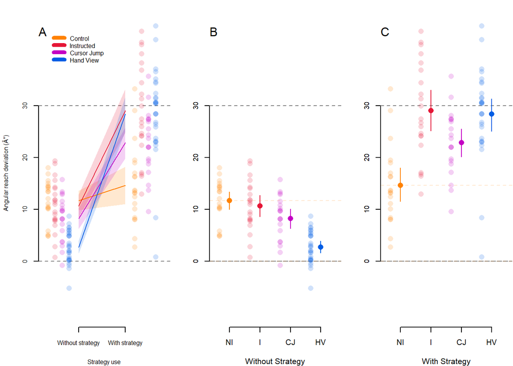

```r
plotReachAfterEffects()
```

## Test for Reach Aftereffects

First, we tested whether or not adaptation led to reach aftereffects. We performed a 2X4 mixed design ANOVA with session (aligned or rotated) as a within-subject factor and group as a between-subject factor.

```r
NoCANOVA()
```

```
## $ANOVA
##              Effect DFn DFd         F            p p<.05       ges
## 2         diffgroup   3  86  16.57615 1.386109e-08     * 0.2998184
## 3           session   1  86 373.02348 5.033611e-33     * 0.5295135
## 4 diffgroup:session   3  86  22.60505 6.977690e-11     * 0.1698537
```

We see that there were implicit reach aftereffects after adaptation due to the significant main effect of session. However, since the interaction between group and session was also significant, it is possible that the effect of session was modulated by groups (i.e. the effect of session occurs differently for at least one group). Thus, we performed planned follow-up tests comparing each group to itself between the two sessions.

```r
NoCursorComparisonMeans()
```

```
## Contrasts set to contr.sum for the following variables: diffgroup
```

```
##  diffgroup  session   lsmean    SE  df lower.CL upper.CL
##  30explicit aligned    1.196 0.897 141   -0.577    2.970
##  30implicit aligned    1.017 0.911 142   -0.785    2.819
##  cursorjump aligned   -0.670 0.911 142   -2.471    1.132
##  handview   aligned   -0.761 0.814 134   -2.370    0.848
##  30explicit exclusive 12.120 0.897 141   10.346   13.893
##  30implicit exclusive 13.234 0.911 142   11.433   15.036
##  cursorjump exclusive  7.893 0.911 142    6.092    9.695
##  handview   exclusive  2.411 0.814 134    0.802    4.020
##
## Warning: EMMs are biased unless design is perfectly balanced
## Confidence level used: 0.95
```

```r
getNoCurComparisonEffSize(method='sidak', type='all')
```

```
## Contrasts set to contr.sum for the following variables: diffgroup
```

```
##  contrast                           estimate    SE df t.ratio p.value
##  AL.Instr vs. ROT.Instr               -10.92 0.923 86 -11.830 <.0001
##  AL.Non-Instr vs. ROT.Non-Instr       -12.22 0.946 86 -12.912 <.0001
##  AL.Cursor Jump vs. ROT.Cursor Jump    -8.56 0.946 86  -9.050 <.0001
##  AL.Handview vs. ROT.Handview          -3.17 0.786 86  -4.037 0.0005
##
## P value adjustment: sidak method for 4 tests
##                             contrast etasquared
## 1             AL.Instr vs. ROT.Instr  0.6193710
## 2     AL.Non-Instr vs. ROT.Non-Instr  0.6596934
## 3 AL.Cursor Jump vs. ROT.Cursor Jump  0.4878008
## 4       AL.Handview vs. ROT.Handview  0.1592948
```

Planned follow-up tests show that the aligned and rotated sessions differed significantly for each group. Note that effect sizes are provided with eta-squared, which is interpreted as the percent of variance in angular reach deviation that is accounted for by the difference between the two sessions.

To investigate which group differed from each other in the exclusive (without strategy) no-cursor trials, we conducted pairwise comparisons of each group compared to the Control group, as well as a comparison between the Cursor Jump and Hand View group.

```r
getNoCurComparisonEffSize(type='exclusive')
```

```
## Contrasts set to contr.sum for the following variables: diffgroup
```

```
##  contrast                  estimate   SE df t.ratio p.value
##  Instr vs. Non-instr          -1.11 1.54 86 -0.722  0.9224
##  Cursor Jump vs. Non-instr    -5.34 1.56 86 -3.419  0.0038
##  Hand View vs. Non-Instr     -10.82 1.44 86 -7.538  <.0001
##  Cursor Jump vs. Hand View     5.48 1.44 86  3.818  0.0010
##
## P value adjustment: sidak method for 4 tests
##                    contrast  etasquared
## 1       Instr vs. Non-instr 0.006025884
## 2 Cursor Jump vs. Non-instr 0.119643134
## 3   Hand View vs. Non-Instr 0.397822862
## 4 Cursor Jump vs. Hand View 0.144942718
```

We find that the Cursor Jump and Hand View groups are significantly different from the Control group, suggesting that implicit reach aftereffects for these groups are lower. Moreover, a significant difference between the Cursor Jump and Hand View group, suggests how implicit reach aftereffects are further reduced for the Hand View group.

## PDP-type analysis (Strategy Use)

Following analyses for reach aftereffects, we assessed the effect of our manipulations of external error attribution on awareness of the perturbation, using a process dissociation procedure (PDP; Werner et al., 2015; Modchalingam et al., 2019). First, we implemented a baseline-correction procedure, by subtracting no-cursor reaches in the aligned session from no-cursor with strategy and no-cursor without strategy trials, respectively. We then compared angular reach deviations per participant when either including any strategy they learned during adaptation training (no-cursor with strategy) or excluding such a strategy (no-cursor without strategy). We expect that our manipulations will increase participants’ awareness of the external nature of the perturbation and lead to a difference between without strategy and with strategy trials. This is because with strategy trials capture the explicitly available strategy. On the other hand, a lack of awareness will not lead to a difference between without and with strategy trials. We performed a 2X4 mixed design ANOVA with strategy use as a within-subject factor (with or without strategy) and group as a between-subject factor.

```r
RAEANOVA()
```

```
## $ANOVA
##               Effect DFn DFd          F            p p<.05       ges
## 2          diffgroup   3  86   6.778685 3.710780e-04     * 0.1175839
## 3           strategy   1  86 285.492988 4.620492e-29     * 0.5916683
## 4 diffgroup:strategy   3  86  28.677647 6.018123e-13     * 0.3039368
```

We see that the main effects of group and strategy, as well as their interaction were significant. This suggests that angular reach deviations from at least one group differed from the other groups, when either using or not using a strategy. Planned follow-up tests were necessary to determine which of the groups differed.

```r
RAEComparisonMeans()
```

```
## Contrasts set to contr.sum for the following variables: diffgroup
```

```
##  diffgroup  strategy  lsmean   SE  df lower.CL upper.CL
##  30explicit exclusive  10.67 1.40 170    7.905    13.43
##  30implicit exclusive  11.74 1.42 170    8.929    14.55
##  cursorjump exclusive   8.29 1.42 170    5.484    11.10
##  handview   exclusive   2.78 1.25 166    0.313     5.25
##  30explicit inclusive  29.06 1.40 170   26.296    31.82
##  30implicit inclusive  14.66 1.42 170   11.847    17.47
##  cursorjump inclusive  22.86 1.42 170   20.055    25.67
##  handview   inclusive  28.43 1.25 166   25.959    30.89
##
## Warning: EMMs are biased unless design is perfectly balanced
## Confidence level used: 0.95
```

```r
getRAEComparisonEffSize(method='sidak')
```

```
## Contrasts set to contr.sum for the following variables: diffgroup
```

```
##  contrast                            estimate   SE df t.ratio p.value
##  WO.Instr vs. WITH.Instr               -18.39 1.86 86  -9.877 <.0001
##  WO.Non-Instr vs. WITH.Non-Instr        -2.92 1.91 86  -1.529 0.4267
##  WO.Cursor Jump vs. WITH.Cursor Jump   -14.57 1.91 86  -7.637 <.0001
##  WO.Handview vs. WITH.Handview         -25.65 1.58 86 -16.185 <.0001
##
## P value adjustment: sidak method for 4 tests
##                              contrast etasquared
## 1             WO.Instr vs. WITH.Instr 0.53145073
## 2     WO.Non-Instr vs. WITH.Non-Instr 0.02647764
## 3 WO.Cursor Jump vs. WITH.Cursor Jump 0.40410183
## 4       WO.Handview vs. WITH.Handview 0.75284197
```

The tests confirmed our conclusions from the figure. All groups, except the Control group, showed significantly different angular reach deviations when comparing reaches using a strategy to reaches when they are not using a strategy. This suggests unawareness of learning for the Control group. Note that effect sizes are provided with eta-squared, which is interpreted as the percent of variance in angular reach deviation that is accounted for by the difference between using and not using a strategy.

# Localization

We also investigated how manipulating the extent of external error attribution affected participants’ hand location estimates.

we analyzed estimates of hand position in Active Localization and Passive Localization trials, before and after rotation training. We calculated the angular difference between a line connecting the home position to the point where the participant’s unseen right hand movement ended, and a line connecting the home position to the participant’s perceived hand location, i.e. their touchscreen response using the left hand. For us to be able to calculate these angular difference measures appropriately, the touchscreen and monitor position must be coordinated. However, during our analyses of the data, we encountered inconsistencies with the location of the touchscreen responses relative to the arc location. This is because the touchscreen position is fixed, but the monitor can be moved to different positions. Thus, these inconsistencies showed that some of the responses were not centred on where the arc stimuli were expected to be displayed (12 cm from home position). Despite this, responses still fell within the shape of an arc, which allowed us to fix for this problem by implementing a circle fitting procedure that finds a circle of best fit for the responses. Moreover, this procedure also allowed us to account for any participant response biases. The procedure used a fitting algorithm that minimized mean squared errors (MSE), where errors were defined as the difference between the touchscreen response locations and the expected arc stimulus location. The MSE measures were then passed on to an optimizing function (optim in R), which minimized the error to return a best fitting home position, such that the responses were shifted to where we expected it to be (i.e. 12 cm from home position). In short, the circle fitting procedure ensured that any localization shifts we detected in our analyses were not due to technical issues or response biases. Furthermore, we conducted an outlier removal procedure for this fitted data, such that trials with hand movement endpoints beyond ±20° from the arc centre and angular errors beyond ±3 standard deviations from the mean angular error were removed. As participants chose the points on the arc that they moved towards, their movements did not end on all possible points on the arc. To account for this, we used a kernel smoothing method (gaussian kernel with width = 15°) to interpolate changes in hand localization at specific points (50°, 90°, and 130°) for every participant. These locations are the same points where the arc stimuli are centred on in polar coordinates. We then used the mean of these interpolated values at each of the three points, to estimate hand localization errors in active and passive movements for both the aligned and rotated sessions.

## Show the data

Below is a plot of the mean angular shift in hand localization for each group as a function of the three interpoints (50°, 90°, and 130°). Panel 1 shows shifts in hand localization when both proprioceptive information and efference-based predictions are available to the participant. Panel 2 shows shifts in hand localization when only proprioceptive information is available. Panel 3 shows shifts in hand localization measured when subtracting passive from active movements. This difference is what we use as a measure for efference-based predictions. Lines represent the mean angular shift in localization for each group, and corresponding shaded regions represent 95% Confidence Intervals. The right hand side of each panel shows the mean localization shifts and corresponding 95% Confidence Intervals for each group, regardless of Hand Angle.

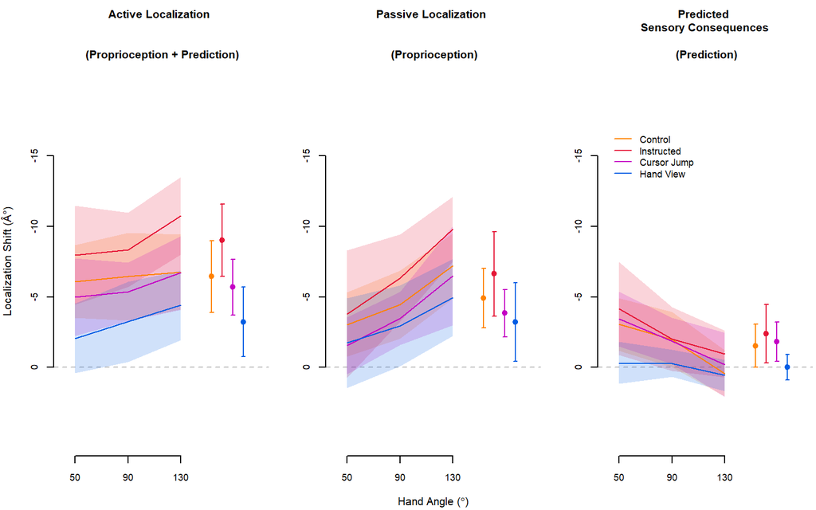

```r
plotLocalizationShift(target='inline')
```

Below is a plot showing individual data points (transparent dots) for shifts in localization according to groups and movement type. For the lower half, solid dots and error bars represent the mean and bootstrapped 95% confidence intervals.

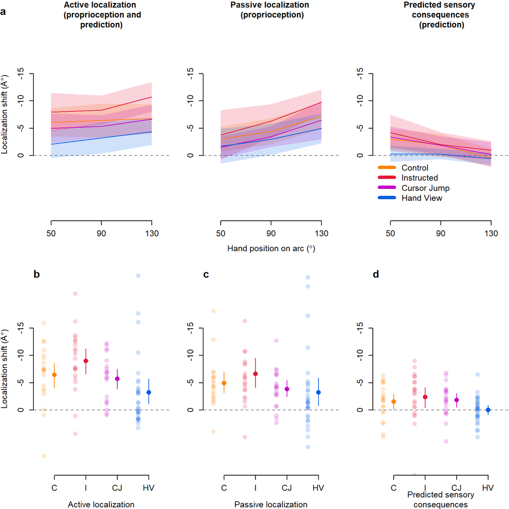

```r
plotLocalizations()
```

## Localization errors differ after rotated training

We first confirmed whether hand position estimates did shift after adaptation to a visuomotor rotation. To do this, we compared hand localization errors in the aligned session from those in the rotated session. We ran a 2X2X4 mixed design ANOVA with session (*rotated_b* in data; aligned and rotated) and movement type (*passive_b* in data; active and passive) as within-subjects factors and group (instructed, Control, cursor jump, and hand view) as a between-subject factor.

```r
localizationANOVA(test='omnibus')
```

```
## $ANOVA
##                      Effect DFn DFd          F            p p<.05          ges
## 2                     group   3  86 10.2140223 8.027644e-06     * 0.1948349585
## 3                 rotated_b   1  86 82.9722888 2.952983e-14     * 0.1998968369
## 5                 passive_b   1  86  0.2248202 6.365931e-01       0.0001014685
## 4           group:rotated_b   3  86  2.8949588 3.981800e-02     * 0.0254846797
## 6           group:passive_b   3  86  0.2332192 8.730026e-01       0.0003157102
## 7       rotated_b:passive_b   1  86 16.8023316 9.368043e-05     * 0.0044892506
## 8 group:rotated_b:passive_b   3  86  2.4249975 7.114493e-02       0.0019486945
```

We see that rotated_b had a significant main effect, which suggests that hand localization errors after rotated training differed from those before training. We also see other effects which we will investigate further.

## Effect of group and movement type on localization shifts

The other effects show that estimates of hand position do shift despite external error attribution, but the extent of these shifts are modulated by group and movement type. Thus, we ran a 2X4 mixed design ANOVA with movement type (*passive_b*) as a within-subject factor and group as a between-subject factor on localization shifts (i.e. difference in localization error between rotated and aligned sessions).

```r
localizationANOVA(test = 'shifts')
```

```
## $ANOVA
##            Effect DFn DFd         F            p p<.05         ges
## 2           group   3  86  2.894959 3.981800e-02     * 0.084854522
## 3       passive_b   1  86 16.802332 9.368043e-05     * 0.015737408
## 4 group:passive_b   3  86  2.424998 7.114493e-02       0.006875259
```

We see that there is a main effect of group and movement type, but no significant interaction. This suggests that the effects of movement type on shifts in hand position estimates were not modulated by group, and vice-versa. The effect of movement type is expected, given that active movements have both afferent and efferent-based contributions to hand localization, while passive movements only had afferent information. For the group effect, pairwise comparisons show that the Hand View group differs from the Instructed group.

```r
getlocalizationshiftComparisonEffSize()
```

```
## Contrasts set to contr.sum for the following variables: group
```

```
##  contrast                  estimate   SE df t.ratio p.value
##  Instr vs. Non-instr         -2.157 1.73 86 -1.249  0.7660
##  Cursor Jump vs. Non-instr    0.897 1.75 86  0.514  0.9964
##  Hand View vs. Non-Instr      2.437 1.61 86  1.517  0.5747
##  Cursor Jump vs. Instr        3.054 1.73 86  1.769  0.3954
##  Hand View vs. Instr          4.594 1.58 86  2.901  0.0280
##  Cursor Jump vs. Hand View   -1.540 1.61 86 -0.959  0.9176
##
## P value adjustment: sidak method for 6 tests
##                    contrast  etasquared
## 1       Instr vs. Non-instr 0.017822377
## 2 Cursor Jump vs. Non-instr 0.003057757
## 3   Hand View vs. Non-Instr 0.026077544
## 4     Cursor Jump vs. Instr 0.035111440
## 5       Hand View vs. Instr 0.089162186
## 6 Cursor Jump vs. Hand View 0.010574326
```

## Proprioceptive Recalibration

We wanted to test whether each group showed shifts in passive localization. We ran t-tests that compared each group’s magnitude of shifts in passive localization estimates against 0. These were one-tailed t-tests, where the null hypothesis was that the mean is greater than or equal to 0; the alternative hypothesis was that the mean is less than 0. Hence confidence intervals are all from minus infinity. Note that we do not need to control for multiplicity here, as each group is independently compared to zero (i.e., these are not pairwise comparisons).

```r
pasLocTtests()
```

```
## Hand View group proprioceptive recalibration compared to 0:
##
##  One Sample t-test
##
## data:  subdf$prop_recal
## t = -2.3715, df = 28, p-value = 0.01242
## alternative hypothesis: true mean is less than 0
## 95 percent confidence interval:
##        -Inf -0.9099481
## sample estimates:
## mean of x
## -3.219151
##
## Effect Size - Cohen d:
## [1] 0.4403703
##
##
## Instructed group proprioceptive recalibration compared to 0:
##
##  One Sample t-test
##
## data:  subdf$prop_recal
## t = -4.6143, df = 20, p-value = 8.383e-05
## alternative hypothesis: true mean is less than 0
## 95 percent confidence interval:
##       -Inf -4.152556
## sample estimates:
## mean of x
## -6.631075
##
## Effect Size - Cohen d:
## [1] 1.006932
##
##
## Control group proprioceptive recalibration compared to 0:
##
##  One Sample t-test
##
## data:  subdf$prop_recal
## t = -4.8691, df = 19, p-value = 5.329e-05
```

[output cut: 11 more lines]

```
## Cursor Jump group proprioceptive recalibration compared to 0:
##
##  One Sample t-test
##
## data:  subdf$prop_recal
## t = -4.8321, df = 19, p-value = 5.79e-05
## alternative hypothesis: true mean is less than 0
## 95 percent confidence interval:
##       -Inf -2.471709
## sample estimates:
## mean of x
## -3.849077
##
## Effect Size - Cohen d:
## [1] 1.080488
```

From the tests, we see that all groups differed significantly from 0, suggesting that all groups showed changes in proprioceptive estimates. Note that effect sizes are provided with Cohen’s d, which is in standard deviation units. Thus, it indicates how many standard deviations the mean shift for a group is different from zero. Here, all Cohen’s d values are relatively similar, except for the Hand View group.

## Predicted Sensory Consequences

Next, we ran t-tests that compared each group’s magnitude of changes in predicted sensory consequences against 0.

```r
predConsTtests()
```

```
## Hand View group predicted sensory consequences compared to 0:
##
##  One Sample t-test
##
## data:  subdf$pred_update
## t = -0.036821, df = 28, p-value = 0.4854
## alternative hypothesis: true mean is less than 0
## 95 percent confidence interval:
##       -Inf 0.7239956
## sample estimates:
##  mean of x
## -0.0160175
##
## Effect Size - Cohen d:
## [1] 0.006837449
##
##
## Instructed group predicted sensory consequences compared to 0:
##
##  One Sample t-test
##
## data:  subdf$pred_update
## t = -2.4107, df = 20, p-value = 0.01283
## alternative hypothesis: true mean is less than 0
## 95 percent confidence interval:
##        -Inf -0.6773985
## sample estimates:
## mean of x
## -2.380476
##
## Effect Size - Cohen d:
## [1] 0.5260632
##
##
## Control group predicted sensory consequences compared to 0:
##
##  One Sample t-test
##
## data:  subdf$pred_update
## t = -2.1013, df = 19, p-value = 0.02459
```

[output cut: 11 more lines]

```
## Cursor Jump group predicted sensory consequences compared to 0:
##
##  One Sample t-test
##
## data:  subdf$pred_update
## t = -2.7513, df = 19, p-value = 0.00635
## alternative hypothesis: true mean is less than 0
## 95 percent confidence interval:
##        -Inf -0.6820571
## sample estimates:
## mean of x
## -1.835863
##
## Effect Size - Cohen d:
## [1] 0.6152064
```

From the tests, we see that only the Hand View group did not significantly differ from 0, suggesting that the Hand View group had a reduction of updates in predicted sensory consequences. Note that effect sizes are provided with Cohen’s d, which is in standard deviation units. Thus, it indicates how many standard deviations the mean shift for a group is different from zero. Here, only the Hand View group has a very small effect size.

# Contributions of Proprioception and Predicted Sensory Consequences on Reach Aftereffects

Next, we tested whether both afferent and efferent-based changes predict/contribute to implicit motor changes.

To visualize the data, we plot the relationship of passive localization and aftereffects, as well as predictions and aftereffects, individually (a and b in figure). Note that we did perform a Pearson product moment correlation test for these two and found a significant relationship for both, but we only include it as analyses extra to the manuscript (i.e., the main test is the multiple regression below). For the extra analyses, refer to the other R Markdown document, AnalysesSupp.

```
##
## Call:
## lm(formula = reachdev ~ prop_recal)
##
## Residuals:
##      Min       1Q   Median       3Q      Max
## -11.8236  -4.0634  -0.2784   3.7385  10.8567
##
## Coefficients:
##             Estimate Std. Error t value Pr(>|t|)
## (Intercept)  6.39900    0.67956   9.416  5.7e-15 ***
## prop_recal  -0.31817    0.09128  -3.486 0.000768 ***
## ---
## Signif. codes:  0 '***' 0.001 '**' 0.01 '*' 0.05 '.' 0.1 ' ' 1
##
## Residual standard error: 5.118 on 88 degrees of freedom
## Multiple R-squared:  0.1213, Adjusted R-squared:  0.1113
## F-statistic: 12.15 on 1 and 88 DF,  p-value: 0.000768
```

```
##
## Call:
## lm(formula = reachdev ~ pred_update)
##
## Residuals:
##     Min      1Q  Median      3Q     Max
## -11.191  -3.720  -0.292   4.271   9.495
##
## Coefficients:
##             Estimate Std. Error t value Pr(>|t|)
## (Intercept)   7.2109     0.5896  12.231  < 2e-16 ***
## pred_update  -0.4797     0.1635  -2.933  0.00427 **
## ---
## Signif. codes:  0 '***' 0.001 '**' 0.01 '*' 0.05 '.' 0.1 ' ' 1
##
## Residual standard error: 5.211 on 88 degrees of freedom
## Multiple R-squared:  0.08907,    Adjusted R-squared:  0.07872
## F-statistic: 8.605 on 1 and 88 DF,  p-value: 0.004274
##
##
## Call:
## lm(formula = data$RAE_pred ~ data$exclude)
##
## Residuals:
##     Min      1Q  Median      3Q     Max
## -9.6036 -1.4597 -0.3365  1.1890  8.3514
##
## Coefficients:
##              Estimate Std. Error t value Pr(>|t|)
## (Intercept)    5.5449     0.4617  12.010  < 2e-16 ***
## data$exclude   0.2927     0.0485   6.035 3.69e-08 ***
## ---
## Signif. codes:  0 '***' 0.001 '**' 0.01 '*' 0.05 '.' 0.1 ' ' 1
##
## Residual standard error: 2.484 on 88 degrees of freedom
## Multiple R-squared:  0.2927, Adjusted R-squared:  0.2847
## F-statistic: 36.42 on 1 and 88 DF,  p-value: 3.689e-08
```

```
##
## Call:
## lm(formula = reachdev ~ prop_recal)
##
## Residuals:
##     Min      1Q  Median      3Q     Max
## -22.689 -11.595   1.168  10.209  25.793
##
## Coefficients:
##             Estimate Std. Error t value Pr(>|t|)
## (Intercept)  17.0495     1.5807  10.786   <2e-16 ***
## prop_recal    0.1343     0.2123   0.633    0.529
## ---
## Signif. codes:  0 '***' 0.001 '**' 0.01 '*' 0.05 '.' 0.1 ' ' 1
##
## Residual standard error: 11.9 on 88 degrees of freedom
## Multiple R-squared:  0.004528,   Adjusted R-squared:  -0.006784
## F-statistic: 0.4003 on 1 and 88 DF,  p-value: 0.5286
```

```
##
## Call:
## lm(formula = reachdev ~ pred_update)
##
## Residuals:
##     Min      1Q  Median      3Q     Max
## -21.443 -11.527   2.162   9.044  26.626
##
## Coefficients:
##             Estimate Std. Error t value Pr(>|t|)
## (Intercept)  17.2727     1.3277  13.009   <2e-16 ***
## pred_update   0.6344     0.3682   1.723   0.0885 .
## ---
## Signif. codes:  0 '***' 0.001 '**' 0.01 '*' 0.05 '.' 0.1 ' ' 1
##
## Residual standard error: 11.73 on 88 degrees of freedom
## Multiple R-squared:  0.03262,    Adjusted R-squared:  0.02163
## F-statistic: 2.968 on 1 and 88 DF,  p-value: 0.08846
##
##
## Call:
## lm(formula = data$EXP_pred ~ data$explicit)
##
## Residuals:
##     Min      1Q  Median      3Q     Max
## -5.9458 -1.5432  0.0066  1.4134  7.4035
##
## Coefficients:
##               Estimate Std. Error t value Pr(>|t|)
## (Intercept)   15.65424    0.46053  33.992   <2e-16 ***
## data$explicit  0.04787    0.02276   2.103   0.0383 *
## ---
## Signif. codes:  0 '***' 0.001 '**' 0.01 '*' 0.05 '.' 0.1 ' ' 1
##
## Residual standard error: 2.547 on 88 degrees of freedom
## Multiple R-squared:  0.04787,    Adjusted R-squared:  0.03705
## F-statistic: 4.424 on 1 and 88 DF,  p-value: 0.03829
```

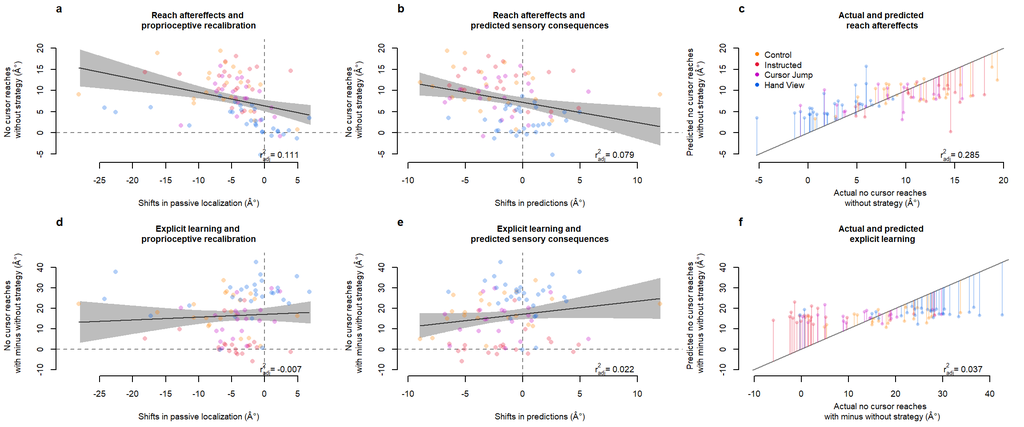

```r
plotPropPredRelationships()
```

From panels a and b of the plot, we see that there is a relationship between predictions and aftereffects, as well as passive localization and aftereffects. For these plots and the regression below, we pooled data from all individuals across all groups together. One concern could be that we are only detecting a relationship because of a group effect that is leading to a spurious correlation. However, even after taking into account the group effect, these predictors are still statistically significant. (See AnalysesSupp for these tests).

We then performed a multiple regression, where measures of aftereffects was the dependent variable, and both passive localization (or recalibrated proprioception) and predicted sensory consequences were the predictors.

```r
getPropPredGLM()
```

```
##
## Call:
## glm(formula = RAE ~ pred_update + prop_recal)
##
## Deviance Residuals:
##      Min        1Q    Median        3Q       Max
## -11.0729   -3.9077   -0.0138    3.6671   11.7894
##
## Coefficients:
##             Estimate Std. Error t value Pr(>|t|)
## (Intercept)  8.64276    1.44935   5.963 5.18e-08 ***
## pred_update -0.09569    0.05477  -1.747  0.08415 .
## prop_recal  -0.33576    0.09079  -3.698  0.00038 ***
## ---
## Signif. codes:  0 '***' 0.001 '**' 0.01 '*' 0.05 '.' 0.1 ' ' 1
##
## (Dispersion parameter for gaussian family taken to be 25.5931)
##
##     Null deviance: 2622.9  on 89  degrees of freedom
## Residual deviance: 2226.6  on 87  degrees of freedom
## AIC: 552.17
##
## Number of Fisher Scoring iterations: 2
##
##
## Call:
## lm(formula = RAE ~ pred_update + prop_recal)
##
## Residuals:
##      Min       1Q   Median       3Q      Max
## -11.0729  -3.9077  -0.0138   3.6671  11.7894
##
## Coefficients:
##             Estimate Std. Error t value Pr(>|t|)
## (Intercept)  8.64276    1.44935   5.963 5.18e-08 ***
## pred_update -0.09569    0.05477  -1.747  0.08415 .
## prop_recal  -0.33576    0.09079  -3.698  0.00038 ***
## ---
## Signif. codes:  0 '***' 0.001 '**' 0.01 '*' 0.05 '.' 0.1 ' ' 1
##
## Residual standard error: 5.059 on 87 degrees of freedom
## Multiple R-squared:  0.1511, Adjusted R-squared:  0.1316
## F-statistic: 7.743 on 2 and 87 DF,  p-value: 0.0008041
##
## The deltaR-square values: the change in the R-square
##       observed when a single term is removed.
## Same as the square of the 'semi-partial correlation coefficient'
##             deltaRsquare
## pred_update   0.02978361
## prop_recal    0.13343862
##     Variables      VIF
## 1  prop_recal 1.012451
## 2 pred_update 1.012451
```

```r
getPropPredCorrelation()
```

```
##
##  Pearson's product-moment correlation
##
## data:  newdf$prop_recal and newdf$pred_update
## t = -2.7688, df = 88, p-value = 0.00686
## alternative hypothesis: true correlation is not equal to 0
## 95 percent confidence interval:
##  -0.46302935 -0.08072409
## sample estimates:
##        cor
## -0.2830828
```

Next, we calculated the predicted reach aftereffects from our model and compared these with the actual/observed reach aftereffects from our experiment (panel c in the plot above).To calculate the predicted reach aftereffects, we refer to values from our model. The equation is:

predicted RAE = Intercept + Prediction_Coeff(actual_prediction) + Proprioception_Coeff(actual_proprioception)

Alternatively, we provide further support for the relationships of each component of hand localization with implicit aftereffects, by showing the lack of such a relationship with explicit learning (i.e. with minus without strategy no-cursor trials; panels d to f).

```r
getPropPredExpRelationships()
```

```
##
## Call:
## lm(formula = explicit ~ prop_recal, data = dat)
##
## Residuals:
##     Min      1Q  Median      3Q     Max
## -22.689 -11.595   1.168  10.209  25.793
##
## Coefficients:
##             Estimate Std. Error t value Pr(>|t|)
## (Intercept)  17.0495     1.5807  10.786   <2e-16 ***
## prop_recal    0.1343     0.2123   0.633    0.529
## ---
## Signif. codes:  0 '***' 0.001 '**' 0.01 '*' 0.05 '.' 0.1 ' ' 1
##
## Residual standard error: 11.9 on 88 degrees of freedom
## Multiple R-squared:  0.004528,   Adjusted R-squared:  -0.006784
## F-statistic: 0.4003 on 1 and 88 DF,  p-value: 0.5286
##
##
## Call:
## lm(formula = explicit ~ pred_update, data = dat)
##
## Residuals:
##     Min      1Q  Median      3Q     Max
## -21.443 -11.527   2.162   9.044  26.626
##
## Coefficients:
##             Estimate Std. Error t value Pr(>|t|)
## (Intercept)  17.2727     1.3277  13.009   <2e-16 ***
## pred_update   0.6344     0.3682   1.723   0.0885 .
## ---
## Signif. codes:  0 '***' 0.001 '**' 0.01 '*' 0.05 '.' 0.1 ' ' 1
##
## Residual standard error: 11.73 on 88 degrees of freedom
## Multiple R-squared:  0.03262,    Adjusted R-squared:  0.02163
## F-statistic: 2.968 on 1 and 88 DF,  p-value: 0.08846
##
##
## Call:
## lm(formula = explicit ~ prop_recal + pred_update, data = dat)
##
## Residuals:
##     Min      1Q  Median      3Q     Max
## -24.362 -10.252   2.269   8.902  25.882
##
## Coefficients:
##             Estimate Std. Error t value Pr(>|t|)
## (Intercept)  18.6040     1.7399   10.69   <2e-16 ***
## prop_recal    0.2570     0.2177    1.18   0.2411
## pred_update   0.7623     0.3831    1.99   0.0497 *
## ---
## Signif. codes:  0 '***' 0.001 '**' 0.01 '*' 0.05 '.' 0.1 ' ' 1
##
## Residual standard error: 11.71 on 87 degrees of freedom
## Multiple R-squared:  0.04787,    Adjusted R-squared:  0.02598
## F-statistic: 2.187 on 2 and 87 DF,  p-value: 0.1184
```

## Extra analyses for residual structure in regression

```r
getSqrtPasLoc()
```

```
##
## Call:
## lm(formula = exclude ~ prop_recal_sqrt + pred_update, data = dat)
##
## Residuals:
##     Min      1Q  Median      3Q     Max
## -9.2272 -3.0729 -0.8881  3.4165 16.6821
##
## Coefficients:
##                 Estimate Std. Error t value Pr(>|t|)
## (Intercept)       4.1188     0.6890   5.978 4.86e-08 ***
## prop_recal_sqrt  -1.7896     0.2806  -6.377 8.41e-09 ***
## pred_update      -0.5985     0.1370  -4.368 3.45e-05 ***
## ---
## Signif. codes:  0 '***' 0.001 '**' 0.01 '*' 0.05 '.' 0.1 ' ' 1
##
## Residual standard error: 4.326 on 87 degrees of freedom
## Multiple R-squared:  0.3792, Adjusted R-squared:  0.3649
## F-statistic: 26.57 on 2 and 87 DF,  p-value: 9.836e-10
##
##
## Call:
## lm(formula = exclude ~ prop_recal + pred_update, data = dat)
##
## Residuals:
##     Min      1Q  Median      3Q     Max
## -9.6900 -3.2806 -0.7717  3.6503 14.3770
##
## Coefficients:
##             Estimate Std. Error t value Pr(>|t|)
## (Intercept)  4.98443    0.68624   7.263 1.51e-10 ***
## prop_recal  -0.42979    0.08588  -5.005 2.89e-06 ***
## pred_update -0.69371    0.15109  -4.591 1.47e-05 ***
## ---
## Signif. codes:  0 '***' 0.001 '**' 0.01 '*' 0.05 '.' 0.1 ' ' 1
##
## Residual standard error: 4.618 on 87 degrees of freedom
## Multiple R-squared:  0.2927, Adjusted R-squared:  0.2764
## F-statistic:    18 on 2 and 87 DF,  p-value: 2.87e-07
```

Even though such a transformation may help to somewhat improve the model, we emphasize that the original (and simpler) model is enough to conclude that proprioceptive recalibration and updated predicted sensory consequences reflect separate processes that are independently related to implicit aftereffects.